# Lecture 06

2026-04-16

# Welcome Back

## Anonymous Activity 1

### QR Code (it’s getting better)

This is anonymous & optional, but helpful to Stats 20,

[figure not shown]

or here is a [direct link](https://www.menti.com/blxdcgm7o3tb)

# The List

## What is a list?

- We have seen vectors and matrices (only one type of data)
- We have seen data frames (can store multiple types)
- Now the list

```r
is.list(rivers) # no this a vector
```

```
[1] FALSE
```

```r
is.list(iris)
```

```
[1] TRUE
```

- iris is a data frame but all data frames are lists

```r
is(iris)
```

```
[1] "data.frame" "list"       "oldClass"   "vector"
```

## List

From the original documentation

> Lists are another kind of data storage. Lists have elements, each of which can contain **any type of R object**, i.e. the elements of a list do not have to be of the same type. List elements are accessed through three different indexing operations. These are explained in detail in Indexing.

Lists are called “generic vectors”, and the basic vector types (e.g., integer, numeric, character etc.) that we have been using are referred to as “atomic vectors”.

## Recall

- The data type in our simple vector must be all the same (all numeric, all character, all logical)
- If there is mixing, we say that R “coerces” the vector to be one type.
- But if data are stored in a list, they can maintain their own type.

## Examples

Recall, an .RData file is a saved environment or a saved workspace. It can contain multiple items

```r
load("state_database.RData")
ls()
```

```
 [1] "euro"           "iris"           "rivers"         "state_data"
 [5] "state.abb"      "state.area"     "state.center"   "state.division"
 [9] "state.name"     "state.region"   "state.x77"
```

Let’s examine the list called state_data

```r
str(state_data)
```

```
List of 10
 $ name       : chr [1:50] "Alabama" "Alaska" "Arizona" "Arkansas" ...
 $ abbrev     : chr [1:50] "AL" "AK" "AZ" "AR" ...
 $ state_stats: num [1:50, 1:8] 3615 365 2212 2110 21198 ...
  ..- attr(*, "dimnames")=List of 2
  .. ..$ : chr [1:50] "Alabama" "Alaska" "Arizona" "Arkansas" ...
  .. ..$ : chr [1:8] "Population" "Income" "Illiteracy" "Life Exp" ...
 $ region     : Factor w/ 4 levels "Northeast","South",..: 2 4 4 2 4 4 1 2 2 2 ...
 $ division   : Factor w/ 9 levels "New England",..: 4 9 8 5 9 8 1 3 3 3 ...
 $ center     :'data.frame':    50 obs. of  2 variables:
  ..$ x: num [1:50] -86.8 -127.2 -111.6 -92.3 -119.8 ...
  ..$ y: num [1:50] 32.6 49.2 34.2 34.7 36.5 ...
 $ area       : num [1:50] 51609 589757 113909 53104 158693 ...
 $ euro       : Named num [1:11] 13.76 40.34 1.96 166.39 5.95 ...
  ..- attr(*, "names")= chr [1:11] "ATS" "BEF" "DEM" "ESP" ...
 $ rivers     : num [1:141] 735 320 325 392 524 ...
 $ iris       :'data.frame':    150 obs. of  5 variables:
  ..$ Sepal.Length: num [1:150] 5.1 4.9 4.7 4.6 5 5.4 4.6 5 4.4 4.9 ...
  ..$ Sepal.Width : num [1:150] 3.5 3 3.2 3.1 3.6 3.9 3.4 3.4 2.9 3.1 ...
  ..$ Petal.Length: num [1:150] 1.4 1.4 1.3 1.5 1.4 1.7 1.4 1.5 1.4 1.5 ...
  ..$ Petal.Width : num [1:150] 0.2 0.2 0.2 0.2 0.2 0.4 0.3 0.2 0.2 0.1 ...
  ..$ Species     : Factor w/ 3 levels "setosa","versicolor",..: 1 1 1 1 1 1 1 1 1 1 ...
```

## What the load() should reveal

[figure not shown]

## How to index (extract) elements from a list

- If you thought to use your tools ($, []) from a data frame you have great instincts, a list offers us many possibilities:

```r
state_data$abbrev ## must be a named element
```

```
 [1] "AL" "AK" "AZ" "AR" "CA" "CO" "CT" "DE" "FL" "GA" "HI" "ID" "IL" "IN" "IA"
[16] "KS" "KY" "LA" "ME" "MD" "MA" "MI" "MN" "MS" "MO" "MT" "NE" "NV" "NH" "NJ"
[31] "NM" "NY" "NC" "ND" "OH" "OK" "OR" "PA" "RI" "SC" "SD" "TN" "TX" "UT" "VT"
[46] "VA" "WA" "WV" "WI" "WY"
```

```r
state_data[2] ## why only one value and not [r,c]
```

```
$abbrev
 [1] "AL" "AK" "AZ" "AR" "CA" "CO" "CT" "DE" "FL" "GA" "HI" "ID" "IL" "IN" "IA"
[16] "KS" "KY" "LA" "ME" "MD" "MA" "MI" "MN" "MS" "MO" "MT" "NE" "NV" "NH" "NJ"
[31] "NM" "NY" "NC" "ND" "OH" "OK" "OR" "PA" "RI" "SC" "SD" "TN" "TX" "UT" "VT"
[46] "VA" "WA" "WV" "WI" "WY"
```

```r
state_data["abbrev"] ## because [] returns a list so
```

```
$abbrev
 [1] "AL" "AK" "AZ" "AR" "CA" "CO" "CT" "DE" "FL" "GA" "HI" "ID" "IL" "IN" "IA"
[16] "KS" "KY" "LA" "ME" "MD" "MA" "MI" "MN" "MS" "MO" "MT" "NE" "NV" "NH" "NJ"
[31] "NM" "NY" "NC" "ND" "OH" "OK" "OR" "PA" "RI" "SC" "SD" "TN" "TX" "UT" "VT"
[46] "VA" "WA" "WV" "WI" "WY"
```

```r
state_data[c(2, 7)] ## works, the $ and the [[]] cannot do this
```

```
$abbrev
 [1] "AL" "AK" "AZ" "AR" "CA" "CO" "CT" "DE" "FL" "GA" "HI" "ID" "IL" "IN" "IA"
[16] "KS" "KY" "LA" "ME" "MD" "MA" "MI" "MN" "MS" "MO" "MT" "NE" "NV" "NH" "NJ"
[31] "NM" "NY" "NC" "ND" "OH" "OK" "OR" "PA" "RI" "SC" "SD" "TN" "TX" "UT" "VT"
[46] "VA" "WA" "WV" "WI" "WY"

$area
 [1]  51609 589757 113909  53104 158693 104247   5009   2057  58560  58876
[11]   6450  83557  56400  36291  56290  82264  40395  48523  33215  10577
[21]   8257  58216  84068  47716  69686 147138  77227 110540   9304   7836
[31] 121666  49576  52586  70665  41222  69919  96981  45333   1214  31055
[41]  77047  42244 267339  84916   9609  40815  68192  24181  56154  97914
```

```r
state_data[c("abbrev", "area")] ## also works same as the previous line
```

```
$abbrev
 [1] "AL" "AK" "AZ" "AR" "CA" "CO" "CT" "DE" "FL" "GA" "HI" "ID" "IL" "IN" "IA"
[16] "KS" "KY" "LA" "ME" "MD" "MA" "MI" "MN" "MS" "MO" "MT" "NE" "NV" "NH" "NJ"
[31] "NM" "NY" "NC" "ND" "OH" "OK" "OR" "PA" "RI" "SC" "SD" "TN" "TX" "UT" "VT"
[46] "VA" "WA" "WV" "WI" "WY"

$area
 [1]  51609 589757 113909  53104 158693 104247   5009   2057  58560  58876
[11]   6450  83557  56400  36291  56290  82264  40395  48523  33215  10577
[21]   8257  58216  84068  47716  69686 147138  77227 110540   9304   7836
[31] 121666  49576  52586  70665  41222  69919  96981  45333   1214  31055
[41]  77047  42244 267339  84916   9609  40815  68192  24181  56154  97914
```

```r
state_data[[2]] ## the double square bracket structure -- different
```

```
 [1] "AL" "AK" "AZ" "AR" "CA" "CO" "CT" "DE" "FL" "GA" "HI" "ID" "IL" "IN" "IA"
[16] "KS" "KY" "LA" "ME" "MD" "MA" "MI" "MN" "MS" "MO" "MT" "NE" "NV" "NH" "NJ"
[31] "NM" "NY" "NC" "ND" "OH" "OK" "OR" "PA" "RI" "SC" "SD" "TN" "TX" "UT" "VT"
[46] "VA" "WA" "WV" "WI" "WY"
```

```r
state_data[["abbrev"]] ## returns a vector, not a list any more
```

```
 [1] "AL" "AK" "AZ" "AR" "CA" "CO" "CT" "DE" "FL" "GA" "HI" "ID" "IL" "IN" "IA"
[16] "KS" "KY" "LA" "ME" "MD" "MA" "MI" "MN" "MS" "MO" "MT" "NE" "NV" "NH" "NJ"
[31] "NM" "NY" "NC" "ND" "OH" "OK" "OR" "PA" "RI" "SC" "SD" "TN" "TX" "UT" "VT"
[46] "VA" "WA" "WV" "WI" "WY"
```

## Study the results

Note the differences.

```r
is(state_data$abbrev)
```

```
[1] "character"           "vector"              "data.frameRowLabels"
[4] "SuperClassMethod"
```

```r
is(state_data[2])
```

```
[1] "list"   "vector"
```

```r
is(state_data["abbrev"])
```

```
[1] "list"   "vector"
```

```r
is(state_data[c(2, 7)])
```

```
[1] "list"   "vector"
```

```r
is(state_data[c("abbrev", "area")])
```

```
[1] "list"   "vector"
```

```r
is(state_data[[2]])
```

```
[1] "character"           "vector"              "data.frameRowLabels"
[4] "SuperClassMethod"
```

```r
is(state_data[["abbrev"]])
```

```
[1] "character"           "vector"              "data.frameRowLabels"
[4] "SuperClassMethod"
```

## Different question – extract “CA”

- A test of your understanding of extraction

```r
state_data$abbrev[5]
```

```
[1] "CA"
```

```r
state_data[2][[1]][5] ## ask why?
```

```
[1] "CA"
```

```r
state_data[[2]][5]
```

```
[1] "CA"
```

- What about “CA” and “NV”? (think sequences and extract by position)

```r
state_data$abbrev[c(5, 28)]
```

```
[1] "CA" "NV"
```

```r
state_data[2][[1]][c(5,28)]
```

```
[1] "CA" "NV"
```

```r
state_data[[2]][c(5, 28)]
```

```
[1] "CA" "NV"
```

## Must be named

- If we try to use names such as “CA” and “NV” instead of 5, 28 – our code will throw an error
- If you have named vector, extraction by name or index number will work:

```r
state_data$euro
```

```
        ATS         BEF         DEM         ESP         FIM         FRF
  13.760300   40.339900    1.955830  166.386000    5.945730    6.559570
        IEP         ITL         LUF         NLG         PTE
   0.787564 1936.270000   40.339900    2.203710  200.482000
```

```r
state_data$euro[c("FRF", "DEM")]
```

```
    FRF     DEM
6.55957 1.95583
```

```r
state_data[["euro"]]
```

```
        ATS         BEF         DEM         ESP         FIM         FRF
  13.760300   40.339900    1.955830  166.386000    5.945730    6.559570
        IEP         ITL         LUF         NLG         PTE
   0.787564 1936.270000   40.339900    2.203710  200.482000
```

```r
state_data[["euro"]][c("FRF", "DEM")]
```

```
    FRF     DEM
6.55957 1.95583
```

## Why do they do this? Why lists?

- If a programmer wants a single long and complex structure and also wants each piece of it to keep its original type, they use a list to contain all of the pieces.
- Recall vectors (atomic ones) coerce the data to keep the type with the highest priority (e.g., logical coerces to integer, integer to numeric, numeric to character etc.)
- Many important model objects are lists, like the results of a regression and more advanced models.
- Many heavily used functions produce lists

## Example

```r
model1 <- lm(mpg ~ wt, data = mtcars) # this is ols (ordinary least squares) in R
is.list(model1)
```

```
[1] TRUE
```

- usually the output of most modeling functions is a list because output is complicated (a mixture of vectors of different type and length)

```r
is.list(summary(model1))
```

```
[1] TRUE
```

```r
summary(model1) # what does it look like
```

```
Call:
lm(formula = mpg ~ wt, data = mtcars)

Residuals:
    Min      1Q  Median      3Q     Max
-4.5432 -2.3647 -0.1252  1.4096  6.8727

Coefficients:
            Estimate Std. Error t value Pr(>|t|)
(Intercept)  37.2851     1.8776  19.858  < 2e-16 ***
wt           -5.3445     0.5591  -9.559 1.29e-10 ***
---
Signif. codes:  0 '***' 0.001 '**' 0.01 '*' 0.05 '.' 0.1 ' ' 1

Residual standard error: 3.046 on 30 degrees of freedom
Multiple R-squared:  0.7528,    Adjusted R-squared:  0.7446
F-statistic: 91.38 on 1 and 30 DF,  p-value: 1.294e-10
```

## Example(cont’d)

- We can extract the specific output from a complex model by understanding lists
- This becomes very important when we want to quanitify model stability by examining thousands of resampled or “bootstrapped” (101A, 101C) models – we would extract the coefficients from each model.
- We see this in machine/statistical learning (101C)

```r
names(model1)
```

```
 [1] "coefficients"  "residuals"     "effects"       "rank"
 [5] "fitted.values" "assign"        "qr"            "df.residual"
 [9] "xlevels"       "call"          "terms"         "model"
```

```r
str(model1) # do you think you could extract the coefficients from our model?
```

```
List of 12
 $ coefficients : Named num [1:2] 37.29 -5.34
  ..- attr(*, "names")= chr [1:2] "(Intercept)" "wt"
 $ residuals    : Named num [1:32] -2.28 -0.92 -2.09 1.3 -0.2 ...
  ..- attr(*, "names")= chr [1:32] "Mazda RX4" "Mazda RX4 Wag" "Datsun 710" "Hornet 4 Drive" ...
 $ effects      : Named num [1:32] -113.65 -29.116 -1.661 1.631 0.111 ...
  ..- attr(*, "names")= chr [1:32] "(Intercept)" "wt" "" "" ...
 $ rank         : int 2
 $ fitted.values: Named num [1:32] 23.3 21.9 24.9 20.1 18.9 ...
  ..- attr(*, "names")= chr [1:32] "Mazda RX4" "Mazda RX4 Wag" "Datsun 710" "Hornet 4 Drive" ...
 $ assign       : int [1:2] 0 1
 $ qr           :List of 5
  ..$ qr   : num [1:32, 1:2] -5.657 0.177 0.177 0.177 0.177 ...
  .. ..- attr(*, "dimnames")=List of 2
  .. .. ..$ : chr [1:32] "Mazda RX4" "Mazda RX4 Wag" "Datsun 710" "Hornet 4 Drive" ...
  .. .. ..$ : chr [1:2] "(Intercept)" "wt"
  .. ..- attr(*, "assign")= int [1:2] 0 1
  ..$ qraux: num [1:2] 1.18 1.05
  ..$ pivot: int [1:2] 1 2
  ..$ tol  : num 1e-07
  ..$ rank : int 2
  ..- attr(*, "class")= chr "qr"
 $ df.residual  : int 30
 $ xlevels      : Named list()
 $ call         : language lm(formula = mpg ~ wt, data = mtcars)
 $ terms        :Classes 'terms', 'formula'  language mpg ~ wt
  .. ..- attr(*, "variables")= language list(mpg, wt)
  .. ..- attr(*, "factors")= int [1:2, 1] 0 1
  .. .. ..- attr(*, "dimnames")=List of 2
  .. .. .. ..$ : chr [1:2] "mpg" "wt"
  .. .. .. ..$ : chr "wt"
  .. ..- attr(*, "term.labels")= chr "wt"
  .. ..- attr(*, "order")= int 1
  .. ..- attr(*, "intercept")= int 1
  .. ..- attr(*, "response")= int 1
  .. ..- attr(*, ".Environment")=<environment: R_GlobalEnv>
  .. ..- attr(*, "predvars")= language list(mpg, wt)
  .. ..- attr(*, "dataClasses")= Named chr [1:2] "numeric" "numeric"
  .. .. ..- attr(*, "names")= chr [1:2] "mpg" "wt"
 $ model        :'data.frame':  32 obs. of  2 variables:
  ..$ mpg: num [1:32] 21 21 22.8 21.4 18.7 18.1 14.3 24.4 22.8 19.2 ...
  ..$ wt : num [1:32] 2.62 2.88 2.32 3.21 3.44 ...
  ..- attr(*, "terms")=Classes 'terms', 'formula'  language mpg ~ wt
  .. .. ..- attr(*, "variables")= language list(mpg, wt)
  .. .. ..- attr(*, "factors")= int [1:2, 1] 0 1
  .. .. .. ..- attr(*, "dimnames")=List of 2
  .. .. .. .. ..$ : chr [1:2] "mpg" "wt"
  .. .. .. .. ..$ : chr "wt"
  .. .. ..- attr(*, "term.labels")= chr "wt"
  .. .. ..- attr(*, "order")= int 1
  .. .. ..- attr(*, "intercept")= int 1
  .. .. ..- attr(*, "response")= int 1
  .. .. ..- attr(*, ".Environment")=<environment: R_GlobalEnv>
  .. .. ..- attr(*, "predvars")= language list(mpg, wt)
  .. .. ..- attr(*, "dataClasses")= Named chr [1:2] "numeric" "numeric"
  .. .. .. ..- attr(*, "names")= chr [1:2] "mpg" "wt"
 - attr(*, "class")= chr "lm"
```

## Suggestions

- Practice constructing sequences using the colon operator (:) and seq(). Those work on numeric data and can increment and decrement.
- Practice constructing any type (logical, character, numeric) using concatenate/combine with c() or even rep()
- Practice on simple vectors such as rivers or extract a vector from iris (e.g., iris$Sepal.Width) and then extract specific values
- Practice extracting from entire lists, for example, take a subset of rows or of column or both. Then parts of rows, parts of columns.
- Work your way up to the list.
- Extraction is a bit like solving a puzzle.

## Attendance Opportunity

### Activity #2: Please Greet Your Neighbor(s)

- You are experts at greeting your neighbors now.
- You need at least one different neighbor each week for your attendance credit (only one photo required)
- You cannot receive credit if it’s only you in the photo
- [Social Isolation and Loneliness are public health problems](https://www.who.int/teams/social-determinants-of-health/demographic-change-and-healthy-ageing/social-isolation-and-loneliness)
- Meet a new classmate, take a photograph.

# Working with Multiple Data Files

## Appending - Adding Rows - Binding Rows

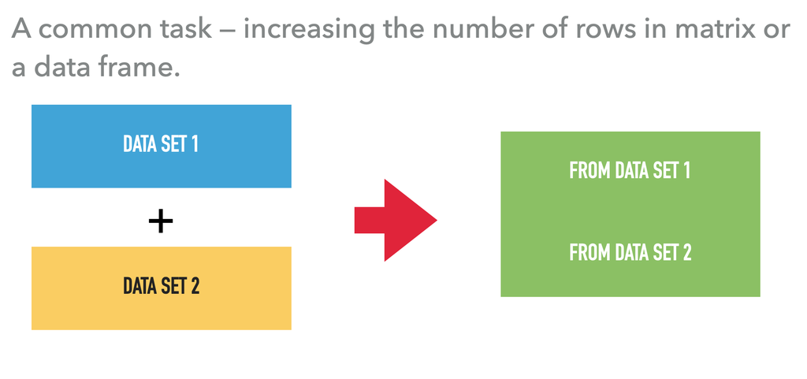

## The context, the why?

- You might have data from multiple time periods (months, years, etc.)
- You wish to combine them into one larger single file for analysis.
- Example: someone has given you 3 csv files for 3 different time periods
- The columns are all the same, but the rows are different and the data covers different time periods
- The data is from [Box Office Mojo, a movie website](https://www.boxofficemojo.com/)
- We take the web locations and save them as an R object

```r
bom00_09_url <- "https://raw.githubusercontent.com/lewv/data-for-example/refs/heads/main/BOM00_09.csv"
bom10_23_url <- "https://raw.githubusercontent.com/lewv/data-for-example/refs/heads/main/BOM10_23.csv"
bom24_url <- "https://raw.githubusercontent.com/lewv/data-for-example/refs/heads/main/BOM24.csv"
```

## The data - 3 files

```r
BOM00_09 <- read.csv(bom00_09_url)
names(BOM00_09)
```

```
[1] "Rank"             "Release.Group"    "Worldwide"        "Domestic"
[5] "Domestic_percent" "Foreign"          "Foreign_percent"  "year"
```

```r
dim(BOM00_09)
```

```
[1] 2000    8
```

```r
head(BOM00_09)
```

```
  Rank                  Release.Group    Worldwide     Domestic
1    0         Mission: Impossible II 54,63,88,108 21,54,09,889
2    1                      Gladiator 46,05,83,960 18,77,05,427
3    2                      Cast Away 42,96,32,142 23,36,32,142
4    3                What Women Want 37,41,11,707 18,28,11,707
5    4                       Dinosaur 34,98,22,765 13,77,48,063
6    5 How the Grinch Stole Christmas 34,58,42,198 26,07,45,620
  Domestic_percent      Foreign Foreign_percent year
1           39.40% 33,09,78,219          60.60% 2000
2           40.80% 27,28,78,533          59.20% 2000
3           54.40% 19,60,00,000          45.60% 2000
4           48.90% 19,13,00,000          51.10% 2000
5           39.40% 21,20,74,702          60.60% 2000
6           75.40%  8,50,96,578          24.60% 2000
```

```r
BOM10_23 <- read.csv(bom10_23_url)
names(BOM10_23)
```

```
[1] "Rank"             "Release.Group"    "Worldwide"        "Domestic"
[5] "Domestic_percent" "Foreign"          "Foreign_percent"  "year"
```

```r
dim(BOM10_23)
```

```
[1] 2800    8
```

```r
head(BOM10_23)
```

```
  Rank                                Release.Group      Worldwide     Domestic
1    0                                  Toy Story 3 1,06,69,69,703 41,50,04,880
2    1                          Alice in Wonderland 1,02,54,67,110 33,41,91,110
3    2 Harry Potter and the Deathly Hallows: Part 1   96,02,83,305 29,59,83,305
4    3                                    Inception   82,82,58,695 29,25,76,195
5    4                          Shrek Forever After   75,26,00,867 23,87,36,787
6    5                   The Twilight Saga: Eclipse   69,84,91,347 30,05,31,751
  Domestic_percent      Foreign Foreign_percent year
1           38.90% 65,19,64,823          61.10% 2010
2           32.60% 69,12,76,000          67.40% 2010
3           30.80% 66,43,00,000          69.20% 2010
4           35.30% 53,56,82,500          64.70% 2010
5           31.70% 51,38,64,080          68.30% 2010
6              43% 39,79,59,596             57% 2010
```

```r
BOM24 <- read.csv(bom24_url)
names(BOM24)
```

```
[1] "Rank"             "Release.Group"    "Worldwide"        "Domestic"
[5] "Domestic_percent" "Foreign"          "Foreign_percent"  "year"
```

```r
dim(BOM24)
```

```
[1] 200   8
```

```r
head(BOM24)
```

```
  Rank                   Release.Group      Worldwide     Domestic
1    0                    Inside Out 2 1,59,59,83,694 63,78,52,840
2    1            Deadpool & Wolverine 1,04,31,80,185 50,69,37,007
3    2                 Despicable Me 4   80,85,37,571 33,25,83,715
4    3                  Dune: Part Two   71,18,44,358 28,21,44,358
5    4 Godzilla x Kong: The New Empire   56,76,50,016 19,63,50,016
6    5                 Kung Fu Panda 4   54,78,20,030 19,35,90,620
  Domestic_percent      Foreign Foreign_percent year
1              40% 95,81,30,854             60% 2024
2           48.60% 53,62,43,178          51.40% 2024
3           41.10% 47,59,53,856          58.90% 2024
4           39.60% 42,97,00,000          60.40% 2024
5           34.60% 37,13,00,000          65.40% 2024
6           35.30% 35,42,29,410          64.70% 2024
```

## rbind()

Short for “row bind”, implies combining or “binding” data on the row dimension

```r
BOM0024 <- rbind(BOM00_09, BOM10_23, BOM24)
names(BOM0024)
```

```
[1] "Rank"             "Release.Group"    "Worldwide"        "Domestic"
[5] "Domestic_percent" "Foreign"          "Foreign_percent"  "year"
```

```r
dim(BOM0024)
```

```
[1] 5000    8
```

```r
head(BOM0024)
```

```
  Rank                  Release.Group    Worldwide     Domestic
1    0         Mission: Impossible II 54,63,88,108 21,54,09,889
2    1                      Gladiator 46,05,83,960 18,77,05,427
3    2                      Cast Away 42,96,32,142 23,36,32,142
4    3                What Women Want 37,41,11,707 18,28,11,707
5    4                       Dinosaur 34,98,22,765 13,77,48,063
6    5 How the Grinch Stole Christmas 34,58,42,198 26,07,45,620
  Domestic_percent      Foreign Foreign_percent year
1           39.40% 33,09,78,219          60.60% 2000
2           40.80% 27,28,78,533          59.20% 2000
3           54.40% 19,60,00,000          45.60% 2000
4           48.90% 19,13,00,000          51.10% 2000
5           39.40% 21,20,74,702          60.60% 2000
6           75.40%  8,50,96,578          24.60% 2000
```

```r
tail(BOM0024)
```

```
     Rank                               Release.Group Worldwide  Domestic
4995  194 Jesus Thirsts: The Miracle of the Eucharist 29,27,121 29,27,121
4996  195                       Buzz House: The Movie 29,10,112         0
4997  196                                       We 12 28,64,154         0
4998  197     Me Contro Te - Il film: Operazione Spie 27,98,501         0
4999  198                              Menudas piezas 27,78,043         0
5000  199                                 Silent Love 27,39,320         0
     Domestic_percent   Foreign Foreign_percent year
4995             100%         0               0 2024
4996                0 29,10,112            100% 2024
4997                0 28,64,154            100% 2024
4998                0 27,98,501            100% 2024
4999                0 27,78,043            100% 2024
5000                0 27,39,320            100% 2024
```

## Result

- can anyone tell me why only a few of the variables are numeric?

```r
str(BOM0024)
```

```
'data.frame':   5000 obs. of  8 variables:
 $ Rank            : int  0 1 2 3 4 5 6 7 8 9 ...
 $ Release.Group   : chr  "Mission: Impossible II" "Gladiator" "Cast Away" "What Women Want" ...
 $ Worldwide       : chr  "54,63,88,108" "46,05,83,960" "42,96,32,142" "37,41,11,707" ...
 $ Domestic        : chr  "21,54,09,889" "18,77,05,427" "23,36,32,142" "18,28,11,707" ...
 $ Domestic_percent: chr  "39.40%" "40.80%" "54.40%" "48.90%" ...
 $ Foreign         : chr  "33,09,78,219" "27,28,78,533" "19,60,00,000" "19,13,00,000" ...
 $ Foreign_percent : chr  "60.60%" "59.20%" "45.60%" "51.10%" ...
 $ year            : int  2000 2000 2000 2000 2000 2000 2000 2000 2000 2000 ...
```

## Solution (Week 3)

- Remove non-numeric characters first, then convert to numeric.
- We could remove the characters (like the comma and percentage) in this manner
- gsub is a “global substitution” function, it searches for the character we specify and then removes all occurrences.
- might be easiest understood reading from the innermost part of the R function

```r
# for commas |> is a "pipe
# The pipe |> means:
# “Take the result on the left and pass it into the function on the right.”"

BOM0024$Worldwide <- gsub(",", "", BOM0024$Worldwide) |> as.numeric()
BOM0024$Domestic  <- gsub(",", "", BOM0024$Domestic) |> as.numeric()
BOM0024$Foreign   <- gsub(",", "", BOM0024$Foreign) |> as.numeric()

# for percent we nested it instead to show the readability of |>
BOM0024$Domestic_percent <- (gsub("%", "", BOM0024$Domestic_percent) |> as.numeric())/100
BOM0024$Foreign_percent  <- (gsub("%", "", BOM0024$Foreign_percent) |> as.numeric())/100
```

## Substitution result

- Always check your work!

```r
str(BOM0024)
```

```
'data.frame':   5000 obs. of  8 variables:
 $ Rank            : int  0 1 2 3 4 5 6 7 8 9 ...
 $ Release.Group   : chr  "Mission: Impossible II" "Gladiator" "Cast Away" "What Women Want" ...
 $ Worldwide       : num  5.46e+08 4.61e+08 4.30e+08 3.74e+08 3.50e+08 ...
 $ Domestic        : num  2.15e+08 1.88e+08 2.34e+08 1.83e+08 1.38e+08 ...
 $ Domestic_percent: num  0.394 0.408 0.544 0.489 0.394 0.754 0.503 0.556 0.531 0.533 ...
 $ Foreign         : num  3.31e+08 2.73e+08 1.96e+08 1.91e+08 2.12e+08 ...
 $ Foreign_percent : num  0.606 0.592 0.456 0.511 0.606 0.246 0.497 0.444 0.469 0.467 ...
 $ year            : int  2000 2000 2000 2000 2000 2000 2000 2000 2000 2000 ...
```

## Looking ahead to next week

- Probably needs more work but… a glimpse of next week
- We log to normalize the variable with a long right tail
- hist() will plot a histogram of a numeric variable
- the rest is about beauty

```r
log_domestic <- log(BOM0024$Domestic)

par(mfrow = c(2,1)) # change default to 2 rows of plots, one column
hist(BOM0024$Domestic, freq = FALSE, col = c("blue", "gold"))
hist(log_domestic, freq = FALSE, col = c("blue", "gold"))
box()
par(mfrow = c(1,1)) # change back to a single plot
```

## Result

[figure not shown]

## Joining/Merging

- This a fundamental data handling skill which borders on intermediate
- As in the previous example, data are broken up into separate files. BUT the information in the columns is different each file and the rows are the same (or mostly the same)
- This is a situation where one is trying to augment data on existing observations with additional data on the column dimension (added characteristics, added variables).
- Generally, you should want a “key” or an identifier variable/column that you can match your datasets on before doing this.
- We are going to get some data for this one

## A little webscraping

- GET SOME (FREE) DATA FROM THE WEB!
- Maybe violate EULAs and other things (so you don’t need to run this part)
- But it’s easy in R (BTW Python is the preferred tool here)
- You will to `install.packages("rvest")` and then `load(rvest)`
- This one is easy, we are going to grab some tables of US data (acquisition)
- Maybe clean them up a little (preparation)
- Save them as R Data Frames
- Then join them to make a more complete dataset

## A Wikipedia page on the US

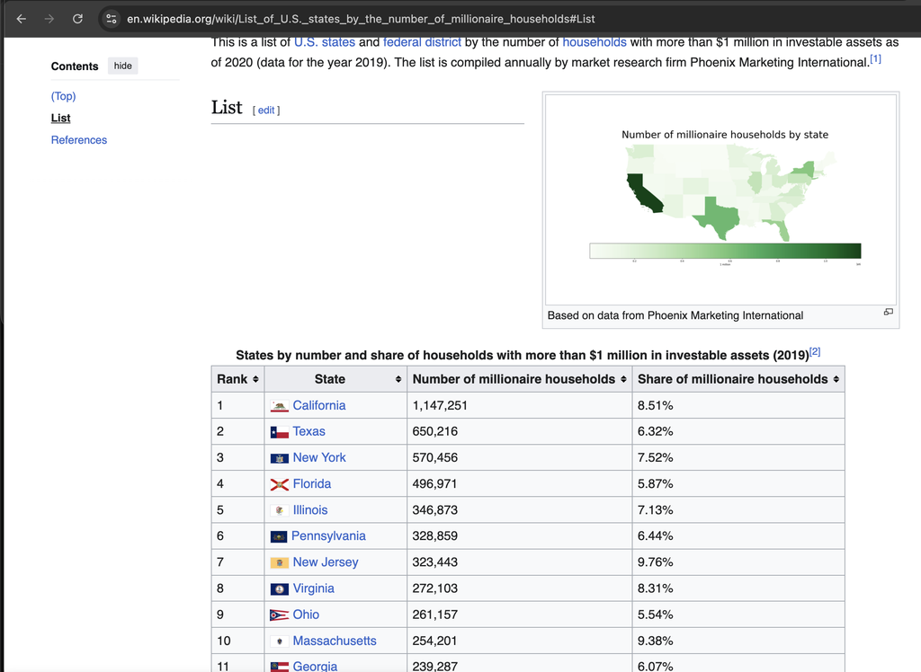

millionaire stats

## Another Wikipedia page on the US

[figure not shown]

research & development

## Activate library, create constants

```r
library(rvest)

millionaires_page <- "https://en.wikipedia.org/wiki/List_of_U.S._states_by_the_number_of_millionaire_households#List"

rd_page <- "https://en.wikipedia.org/wiki/List_of_U.S._states_by_research_and_development_spending#List"
```

See rvest.tidyverse.org more explanations

- The rvest library has a little function read_html() basically reads the web location you give it.
- Typically, when scraping Wikipedia, you want their tables, so we search for tables

```r
millionaires <- read_html(millionaires_page)

millionaires |> html_elements("table")
```

```
{xml_nodeset (2)}
[1] <table class="wikitable nowrap sortable">\n<caption>States by number and  ...
[2] <table class="nowraplinks hlist mw-collapsible mw-collapsed navbox-inner" ...
```

- It turns out to be the first element

## Extract the data table with html_table()

- We decide to extract the first table. Do the same for r_d.
- And check the results, these are data frames

```r
millionaires <- (millionaires_page |> read_html() |> html_table())[[1]]

r_d <- (rd_page |> read_html() |> html_table())[[1]]
```

## Join/Merge two data frames

- The next slide shows a merge in base R, I will show you a “join” in a different package later.
- This is the simplest type, the intersection of two datasets matched on a specific row value(s), typically an ID (state)
- By convention, X (left, first dataset) and Y (right, second dataset)
- We want the intersection of the two
- In our particular example, States and their measurements (why would we care to do such a thing?)

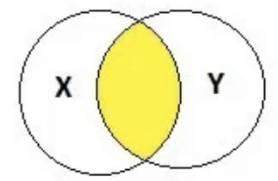

## Code

```r
rich_n_research <- merge(millionaires, r_d, by = "State")
str(rich_n_research)
```

```
'data.frame':   51 obs. of  9 variables:
 $ State                                   : chr  "Alabama" "Alaska" "Arizona" "Arkansas" ...
 $ Rank                                    : int  26 47 18 34 1 16 23 45 43 4 ...
 $ Number of millionaire households        : chr  "94,259" "22,302" "161,014" "51,532" ...
 $ Share of millionaire households         : chr  "4.87%" "8.18%" "6.03%" "4.33%" ...
 $ Nationalrank                            : chr  "26" "50" "20" "42" ...
 $ Expenditures on R&D (millions of US$)[1]: chr  "5,701" "339" "9,056" "892" ...
 $ Expenditures on R&D per capita in US$[2]: chr  "1,006" "410" "1,079" "286" ...
 $ Federal government share in %[3]        : num  25.3 25.7 2.9 4.6 1.6 6.1 0.2 0.1 58.3 6.4 ...
 $ Expenditures on R&D in % of GDP[1]      : chr  "2.54%" "0.67%" "2.43%" "0.69%" ...
```

```r
head(rich_n_research)
```

```
       State Rank Number of millionaire households
1    Alabama   26                           94,259
2     Alaska   47                           22,302
3    Arizona   18                          161,014
4   Arkansas   34                           51,532
5 California    1                        1,147,251
6   Colorado   16                          170,223
  Share of millionaire households Nationalrank
1                           4.87%           26
2                           8.18%           50
3                           6.03%           20
4                           4.33%           42
5                           8.51%            1
6                           7.48%           18
  Expenditures on R&D (millions of US$)[1]
```

[output cut: 20 more lines]

## Need to “clean” the data

- More of this next week but to give you an idea, we are going to create nicely named variables from the old mess ones and clean up the commas
- Always check

```r
rich_n_research$expenditures_rd <- as.numeric(gsub(",", "",
  rich_n_research$`Expenditures on R&D (millions of US$)[1]`))
rich_n_research$millionaire_households <- as.numeric(gsub(",", "",
  rich_n_research$`Number of millionaire households`))

summary(rich_n_research)
```

```
    State                Rank      Number of millionaire households
 Length:51          Min.   : 1.0   Length:51
 Class :character   1st Qu.:13.5   Class :character
 Mode  :character   Median :26.0   Mode  :character
                    Mean   :26.0
                    3rd Qu.:38.5
                    Max.   :51.0
 Share of millionaire households Nationalrank
 Length:51                       Length:51
 Class :character                Class :character
 Mode  :character                Mode  :character



 Expenditures on R&D (millions of US$)[1]
 Length:51
 Class :character
 Mode  :character



 Expenditures on R&D per capita in US$[2] Federal government share in %[3]
 Length:51                                Min.   : 0.100
 Class :character                         1st Qu.: 1.400
 Mode  :character                         Median : 2.600
                                          Mean   : 7.516
                                          3rd Qu.: 9.000
                                          Max.   :58.300
 Expenditures on R&D in % of GDP[1] expenditures_rd  millionaire_households
 Length:51                          Min.   :   339   Min.   :  12849
 Class :character                   1st Qu.:  1472   1st Qu.:  42416
 Mode  :character                   Median :  5701   Median :  94259
                                    Mean   : 13957   Mean   : 164441
                                    3rd Qu.: 12602   3rd Qu.: 228604
                                    Max.   :217976   Max.   :1147251
```

## Some stats and modeling

- We are heading towards Stats 101A but…

```r
cor(rich_n_research$expenditures_rd, rich_n_research$millionaire_households)
```

```
[1] 0.8521751
```

```r
rd_rich_model <- lm(millionaire_households ~ expenditures_rd,
            data = rich_n_research)

summary(rd_rich_model)
```

```
Call:
lm(formula = millionaire_households ~ expenditures_rd, data = rich_n_research)

Residuals:
    Min      1Q  Median      3Q     Max
-128186  -67975  -31506   19937  373420

Coefficients:
                 Estimate Std. Error t value Pr(>|t|)
(Intercept)     8.844e+04  1.626e+04    5.44 1.68e-06 ***
expenditures_rd 5.446e+00  4.777e-01   11.40 2.18e-15 ***
---
Signif. codes:  0 '***' 0.001 '**' 0.01 '*' 0.05 '.' 0.1 ' ' 1

Residual standard error: 105900 on 49 degrees of freedom
Multiple R-squared:  0.7262,    Adjusted R-squared:  0.7206
F-statistic:   130 on 1 and 49 DF,  p-value: 2.178e-15
```

## BUT…

- Why we try to visualize our data

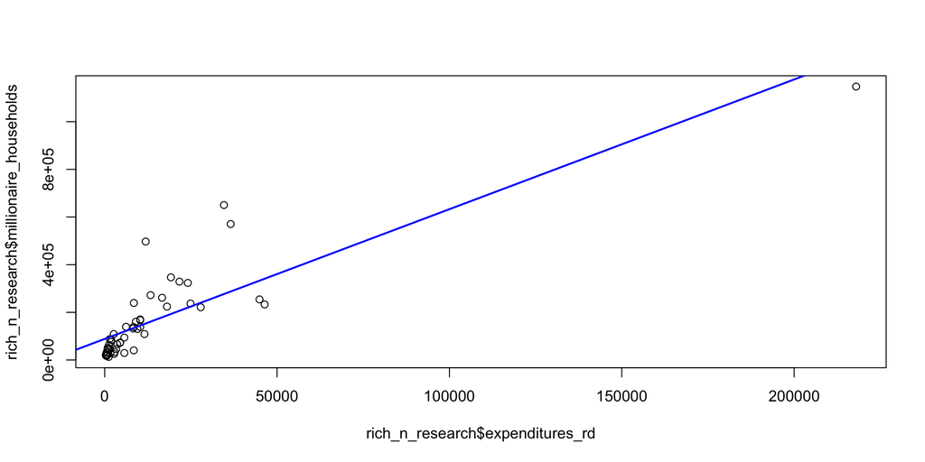

```r
plot(rich_n_research$expenditures_rd, rich_n_research$millionaire_households)
abline(rd_rich_model, col = "blue", lwd = 2)
```

- Clearly an outlier

## Address the outlier

- I am going to remove the outlier and then model again without it

```r
no_california <- rich_n_research[which(!rich_n_research$State %in% c("California")), ]

cor(no_california$expenditures_rd, no_california$millionaire_households)
```

```
[1] 0.7634
```

```r
no_ca_rd_rich_model <- lm(millionaire_households ~ expenditures_rd,
                    data = no_california)

summary(no_ca_rd_rich_model)
```

```
Call:
lm(formula = millionaire_households ~ expenditures_rd, data = no_california)

Residuals:
    Min      1Q  Median      3Q     Max
-256309  -37791  -12882   22082  333196

Coefficients:
                 Estimate Std. Error t value Pr(>|t|)
(Intercept)     51562.491  17525.503   2.942  0.00501 **
expenditures_rd     9.439      1.153   8.188 1.15e-10 ***
---
Signif. codes:  0 '***' 0.001 '**' 0.01 '*' 0.05 '.' 0.1 ' ' 1

Residual standard error: 94210 on 48 degrees of freedom
Multiple R-squared:  0.5828,    Adjusted R-squared:  0.5741
F-statistic: 67.05 on 1 and 48 DF,  p-value: 1.146e-10
```

- Leaving California out moved the regression line a lot

## One more plot to show the difference

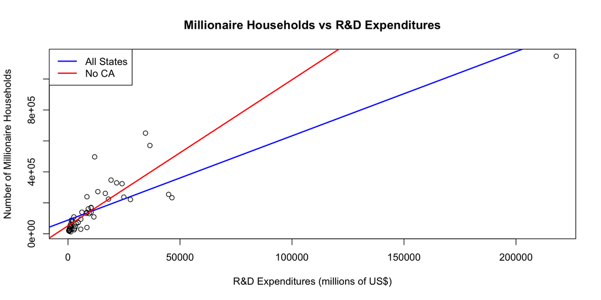

```r
plot(x = rich_n_research$expenditures_rd,
     y = rich_n_research$millionaire_households,
     main = "Millionaire Households vs R&D Expenditures",
     xlab = "R&D Expenditures (millions of US$)",
     ylab = "Number of Millionaire Households")
abline(rd_rich_model, col = "blue", lwd = 2)
abline(no_ca_rd_rich_model, col = "red", lwd = 2)
legend("topleft",
       legend = c("All States", "No CA"),
       col = c("blue", "red"),
       lwd = 2,
       bty = "o")
```

## Takeaways

- The list, a more complex data structure in R
- Working with multiple data frames in R
  - appending (adding more rows or lengthing the columns)
  - joining (adding more columns or widening the rows)
- Got a peek at a data visualization comparing two histograms
- Threw in webscraping using rvest